# Homework #1

Berezovik

2 октября 2017 г

**Задание 1**

- Загрузка данных

```r
data.df<-read.table("http://www.stats.uwo.ca/faculty/braun/data/rnf6080.dat", header = TRUE)
```

- Получение количества строк

```r
print(nrow(data.df))
```

```
## [1] 5069
```

- Получение количества столбцов

```r
print(ncol(data.df))
```

```
## [1] 27
```

- Получение имен столбцов

```r
colnames(data.df)
```

```
##  [1] "X60"   "X4"    "X1"    "X0"    "X0.1"  "X0.2"  "X0.3"  "X0.4"
##  [9] "X0.5"  "X0.6"  "X0.7"  "X0.8"  "X0.9"  "X0.10" "X0.11" "X0.12"
## [17] "X0.13" "X0.14" "X0.15" "X0.16" "X0.17" "X0.18" "X0.19" "X0.20"
## [25] "X0.21" "X0.22" "X0.23"
```

```r
data.df.colnames <- colnames(data.df)
```

- Нахождение значения из 5 строки седьмого столбца.

```r
data.df[5,7]
```

```
## [1] 0
```

- Вывод 2 строки из data.df

```r
print (data.df[2,])
```

```
##   X60 X4 X1 X0 X0.1 X0.2 X0.3 X0.4 X0.5 X0.6 X0.7 X0.8 X0.9 X0.10 X0.11
## 2  60  4  3  0    0    0    0    0    0    0    0    0    0     0     0
##   X0.12 X0.13 X0.14 X0.15 X0.16 X0.17 X0.18 X0.19 X0.20 X0.21 X0.22 X0.23
## 2     0     0     0     0     0     0     0     0     0     0     0     0
```

- Объясните, что делает следующая строка кода names(data.df) <- c(“year”, “month”, “day”, seq(0,23)). Воспользуйтесь функциями head и tail, чтобы просмотреть таблицу. Что представляют собой последние 24 колонки?*

```r
names(data.df) <- c("year", "month", "day", seq(0,23))
head(data.df)
```

```
##   year month day 0 1 2 3 4 5 6 7 8 9 10 11 12 13 14 15 16 17 18 19 20 21
## 1   60     4   2 0 0 0 0 0 0 0 0 0 0  0  0  0  0  0  0  0  0  0  0  0  0
## 2   60     4   3 0 0 0 0 0 0 0 0 0 0  0  0  0  0  0  0  0  0  0  0  0  0
## 3   60     4   4 0 0 0 0 0 0 0 0 0 0  0  0  0  0  0  0  0  0  0  0  0  0
## 4   60     4   5 0 0 0 0 0 0 0 0 0 0  0  0  0  0  0  0  0  0  0  0  0  0
## 5   60     4   6 0 0 0 0 0 0 0 0 0 0  0  0  0  0  0  0  0  0  0  0  0  0
## 6   60     4   7 0 0 0 0 0 0 0 0 0 0  0  0  0  0  0  0  0  0  0  0  0  0
##   22 23
## 1  0  0
## 2  0  0
## 3  0  0
## 4  0  0
## 5  0  0
## 6  0  0
```

```r
tail(data.df)
```

```
##      year month day 0 1 2 3 4 5 6 7 8 9 10 11 12 13 14 15 16 17 18 19 20
## 5064   80    11  25 0 0 0 0 0 0 0 0 0 0  0  0  0  0  0  0  0  0  0  0  0
## 5065   80    11  26 0 0 0 0 0 0 0 0 0 0  0  0  0  0  0  0  0  0  0  0  0
## 5066   80    11  27 0 0 0 0 0 0 0 0 0 0  0  0  0  0  0  0  0  0  0  0  0
## 5067   80    11  28 0 0 0 0 0 0 0 0 0 0  0  0  0  0  0  0  0  0  0  0  0
## 5068   80    11  29 0 0 0 0 0 0 0 0 0 0  0  0  0  0  0  0  0  0  0  0  0
## 5069   80    11  30 0 0 0 0 0 0 0 0 0 0  0  0  0  0  0  0  0  0  0  0  0
##      21 22 23
## 5064  0  0  0
## 5065  0  0  0
## 5066  0  0  0
## 5067  0  0  0
## 5068  0  0  0
## 5069  0  0  0
```

- Добавьте новую колонку с названием daily, в которую запишите сумму крайних правых 24 колонок. Постройте гистограмму по этой колонке. Какие выводы можно сделать?

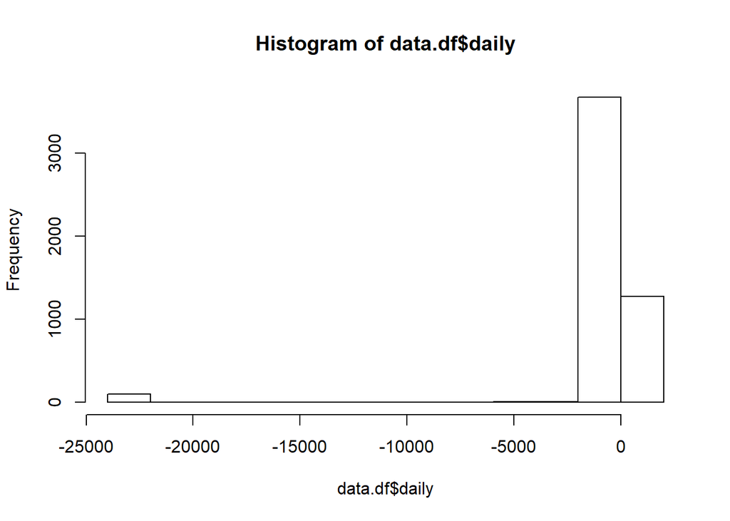

```
Гистограмма показывает отрицательные значения, что есть не очень хорошо.
```

```r
data.df["daily"] <- rowSums(data.df[(length(data.df.colnames)-23):length(data.df.colnames)])
hist(data.df$daily)
```

- Создайте новый датафрейм fixed.df в котром исправьте замеченную ошибку. Постройте новую гистограмму, поясните почему она более корректна.

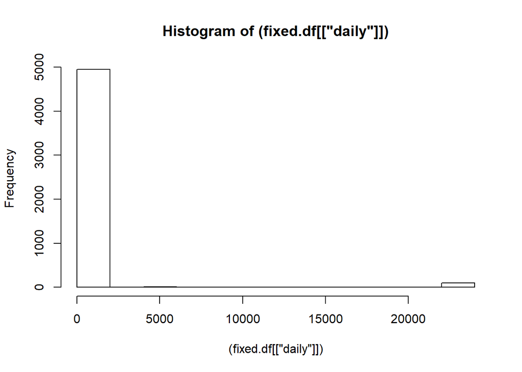

```r
fixed.df = data.df
fixed.df[["daily"]] = abs(fixed.df[["daily"]])
hist((fixed.df[["daily"]]))
```

**Задание 2**

- Для каждой строки кода поясните полученный результат, либо объясните почему она ошибочна.

```r
v <- c("4", "8", "15", "16", "23", "42")
max(v)
```

```
## [1] "8"
```

```r
var(v)
```

```
## [1] 182
```

```r
#sum(v)
```

*max - неверное, var- верно, sum - не считает. Ниже приведен пример корректной работы данных функций.*

```r
x <- c(4,8,15,16,23,42)
max(x)
```

```
## [1] 42
```

```r
var(x)
```

```
## [1] 182
```

```r
sum(x)
```

```
## [1] 108
```

- Для следующих наборов команд поясните полученный результат, либо объясните почему они ошибочна.

```
#v2 <- c("5",7,12)
#v2[2] + 2[3]
```

Невозможно суммирование элементов вектора типа char, так как + работате только с числовыми аргументами.

```
df3 <- data.frame(z1="5",z2=7,z3=12)
df3[1,2] + df3[1,3]
```

Data Frame поддерживает работу с разными типами данными, поэтому в данном случае выполнится сложение.

```
l4 <- list(z1="6", z2=42, z3="49", z4=126)
l4[[2]] + l4[[4]]
l4[2] + l4[4]
```

В списках (листах) оператор [] - выводит список элементов по индексу, а [[]] - сам элемент, поэтому в первом случае выполнится сложение, а во втором - отобразится ошибка

**Работа с функциями и операторами**

- Вывод на экран:
- Числа от 1 до 10000 с инкрементом 372.
- Числа от 1 до 10000 длиной 50.

```r
seq(1, 10000, by = 372)
```

```
##  [1]    1  373  745 1117 1489 1861 2233 2605 2977 3349 3721 4093 4465 4837
## [15] 5209 5581 5953 6325 6697 7069 7441 7813 8185 8557 8929 9301 9673
```

```r
seq(1, 10000, length.out=50)
```

```
##  [1]     1.0000   205.0612   409.1224   613.1837   817.2449  1021.3061
##  [7]  1225.3673  1429.4286  1633.4898  1837.5510  2041.6122  2245.6735
## [13]  2449.7347  2653.7959  2857.8571  3061.9184  3265.9796  3470.0408
## [19]  3674.1020  3878.1633  4082.2245  4286.2857  4490.3469  4694.4082
## [25]  4898.4694  5102.5306  5306.5918  5510.6531  5714.7143  5918.7755
## [31]  6122.8367  6326.8980  6530.9592  6735.0204  6939.0816  7143.1429
## [37]  7347.2041  7551.2653  7755.3265  7959.3878  8163.4490  8367.5102
## [43]  8571.5714  8775.6327  8979.6939  9183.7551  9387.8163  9591.8776
## [49]  9795.9388 10000.0000
```

- Функция rep() повторяет переданный вектор указанное число раз. Объясните разницу между rep(1:5,times=3) и rep(1:5, each=3).

```r
rep(1:5,times=3)
```

```
##  [1] 1 2 3 4 5 1 2 3 4 5 1 2 3 4 5
```

```r
rep(1:5, each=3)
```

```
##  [1] 1 1 1 2 2 2 3 3 3 4 4 4 5 5 5
```

Разница заключается в том, что в первом случаи последовательность чисел от 1 до 5 повторяется 3 раза друг за другом, а во втором случаи каждое число от 1 до 5 повторяется сразу по 3 раза*